# PA1_template.Rmd

Elian de Kleine

7-4-2021

## Loading and preprocessing the data

This code is used to load and preprocess the data:

```r
#download file
temp <- tempfile()
download.file("https://d396qusza40orc.cloudfront.net/repdata%2Fdata%2Factivity.zip",temp)
unzip(temp, "activity.csv")
Activity_monitoring_data <- read.table("activity.csv", sep=",", header=T)
Activity_monitoring_data$date <- as.Date(Activity_monitoring_data$date)

#calculate number of steps taken each day:
Daysteps<-aggregate(Activity_monitoring_data$steps, by=list(Category=Activity_monitoring_data$date), FUN=sum, na.rm=TRUE)
```

## What is mean total number of steps taken per day?

1. Make a histogram of the total number of steps taken each day.

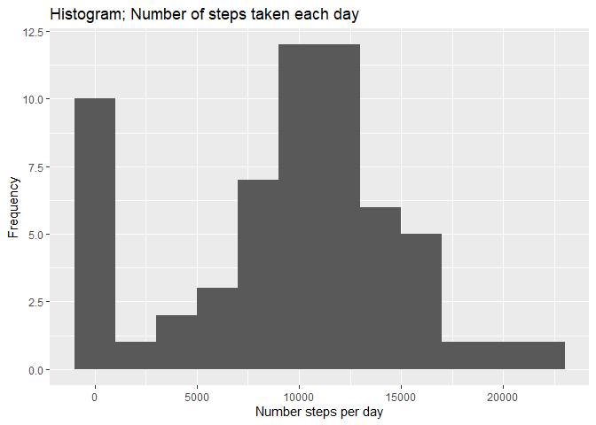

```r
ggplot(Daysteps, aes(x=x)) + geom_histogram(binwidth=2000, na.rm = TRUE)+labs(title="Histogram; Number of steps taken each day",x="Number steps per day", y = "Frequency")
```

2. Calculate and report the **mean** and **median** total number of steps taken per day

```r
mean(Daysteps$x)
```

```
## [1] 9354.23
```

```r
median.default(Daysteps$x)
```

```
## [1] 10395
```

The mean of the total number of steps taken per day is 9354 The median of the total number of steps taken per day is 10395

## What is the average daily activity pattern?

1. Make a time series plot (i.e. `type = "l"`) of the 5-minute interval (x-axis) and the average number of steps taken, averaged across all days (y-axis)

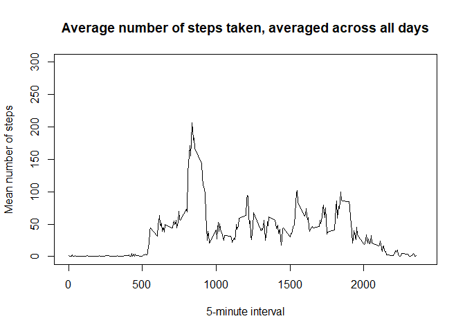

```r
averagesteps<-aggregate(Activity_monitoring_data$steps, by=list(Category=Activity_monitoring_data$interval), na.rm=TRUE, FUN=mean)

plot(averagesteps$Category, averagesteps$x, type = "l", main = "Average number of steps taken, averaged across all days", xlim = c(0, 2400),xlab = "5-minute interval", ylim = c(0, 300), ylab = "Mean number of steps"     )
```

2. Which 5-minute interval, on average across all the days in the dataset, contains the maximum number of steps?

```r
averagesteps[which(averagesteps$x == max(averagesteps$x)),]
```

```
##     Category        x
## 104      835 206.1698
```

The 5-minute interval 835 contains on average the maximum number of steps.

## Imputing missing values

1. Calculate and report the total number of missing values in the dataset (i.e. the total number of rows with `NA`s)

```r
colSums(is.na(Activity_monitoring_data))
```

```
##    steps     date interval
##     2304        0        0
```

The total number of rows with NA’s is 2304, they all appear in the column steps.

2. Devise a strategy for filling in all of the missing values in the dataset. The strategy does not need to be sophisticated. For example, you could use the mean/median for that day, or the mean for that 5-minute interval, etc.

I chose to use the mean for that inteval.

```r
newdata <- Activity_monitoring_data %>%
  group_by(interval) %>%
  mutate(steps = ifelse(is.na(steps), mean(steps, na.rm = TRUE), steps)) %>%
  ungroup()
```

3. Create a new dataset that is equal to the original dataset but with the missing data filled in.

The new dataset I created is named newdata (see r-code question 2.)

```r
Daysteps_newdata<-aggregate(newdata$steps, by=list(Category=newdata$date), FUN=sum)

mean(Daysteps_newdata$x)
```

```
## [1] 10766.19
```

```r
median.default(Daysteps_newdata$x)
```

```
## [1] 10766.19
```

## Are there differences in activity patterns between weekdays and weekends?

1. Create a new factor variable in the dataset with two levels – “weekday” and “weekend” indicating whether a given date is a weekday or weekend day.

```r
newdata$weekday <- format(as.Date(newdata$date), "%a")

newdata$wdays <- as.factor(ifelse((newdata$weekday) %in% c("za", "zo"), "weekend", "weekday"))
```

2. Make a panel plot containing a time series plot (i.e. type = “l”) of the 5-minute interval (x-axis) and the average number of steps taken, averaged across all weekday days or weekend days (y-axis). See the README file in the GitHub repository to see an example of what this plot should look like using simulated data.

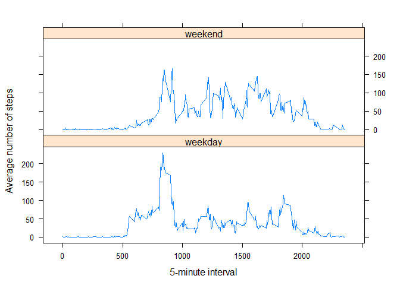

```r
dataPlot <- aggregate(newdata$steps, by = list(newdata$interval, newdata$wdays), FUN = mean)
names(dataPlot) <- c("interval", "weekday", "steps")
xyplot(dataPlot$steps ~ dataPlot$interval | dataPlot$weekday,
       type = "l",
       ylab = "Average number of steps",
       xlab = "5-minute interval",
       layout = c(1, 2))
```